# Tests non paramétriques et du khi-deux

4modIA - 2023-2024

**Résumé :**  
*L’objectif de ce TP est d’illustrer les différents tests vus en cours. N’oubliez pas de vérifier que vous êtes capable de construire ces tests sur le papier !*

```r
library(boot)
library(nortest)
library(ggplot2)
library(gridExtra)
```

# 1 Comparaison de deux échantillons non appariés

On considère le jeu de données *amis* disponible dans la librairie `boot`. Ce jeu de données comporte des mesures de vitesse de voitures sur divers lieux dont certains comportent des signes d’avertissement. On note $(X_1,\ldots,X_n)$ les vitesses mesurées dans des lieux comportant des signes d’avertissement et $(Y_1,\ldots,Y_m)$ les vitesses mesurées dans des lieux sans signe d’avertissement. L’objectif est de déterminer s’il y a une différence significative sur les vitesses en présence ou non de signes d’avertissement.

```r
data(amis)
help(amis)
speed1=amis$speed[amis$warning==1]
speed2=amis$speed[amis$warning==2]
```

Dans un premier temps, faites quelques statistiques descriptives pour vous familiariser avec ces données.

```r
# STATISTIQUES DESCRIPTIVES - A COMPLETER
```

## 1.1 Test de Student

Dans cette section, on suppose que les deux échantillons sont gaussiens : $X_i\sim\mathcal{N}(m_1,\sigma_1^2)$ et $Y_j\sim\mathcal{N}(m_2,\sigma_2^2)$.

- A l’aide de la commande `var.test()`, faites un test d’égalité des variances.

```r
# A completer
```

Qu’en concluez-vous ?  
Réponse : …

- A l’aide de la commande `t.test()`, faites un test d’égalité des moyennes en tenant compte du test précédent sur les variances.

```r
# A COMPLETER
```

Qu’en concluez-vous ?  
Réponse :…

- A l’aide de la commande `t.test()`, testez si la présence de signalisation permet un ralentissement des voitures.

```r
# A COMPLETER
```

Qu’en concluez-vous ?  
Réponse : …

## 1.2 Test de normalité des échantillons

Les tests précédents sont totalement conditionnés à l’hypothèse que chacun des échantillons est gaussien. Nous allons ici nous intéresser à tester la normalité de chacun des échantillons.

- On commence par tracer la droite d’Henry (qqplot) pour chacun des échantillons :

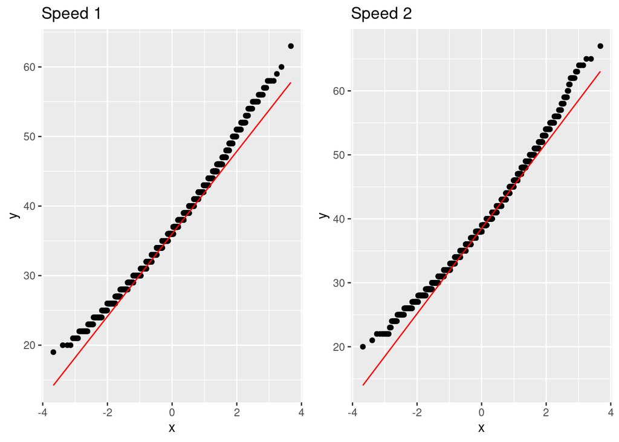

```r
p1 = ggplot(data.frame(y=speed1), aes(sample = y))+
  stat_qq() +
  stat_qq_line(col="red")+
  ggtitle("Speed 1")
p2 = ggplot(data.frame(y=speed2), aes(sample = y))+
  stat_qq() +
  stat_qq_line(col="red")+
  ggtitle("Speed 2")
grid.arrange(p1,p2,ncol=2)
```

Commentaire : …

- Pour chacun des échantillons, tracez la fonction de répartition empirique (à l’aide de `ecdf()`) et superposez celle d’une loi normale de moyenne la moyenne empirique et de variance la variance empirique (à l’aide de `pnorm()`).

```r
# A COMPLETER
```

- A l’aide de la fonction `lillie.test()` de la librairie `nortest`, testez la normalité de chacun des échantillons à l’aide d’un test de Kolmogorov-Smirnov.

```r
# A COMPLETER
```

Commentaire : …

- A l’aide de la fonction `shapiro.test()`, testez la normalité de chacun des échantillons à l’aide d’un test de Shapiro-Wilk.

```r
# A COMPLETER
```

Commentaire : …

## 1.3 Tests non-paramétriques de comparaison de deux échantillons

On ne va plus supposer ici que les échantillons sont distribués selon une loi normale chacun. On ne va faire aucune hypothèse sur la distribution des échantillons.

- A l’aide de la fonction `ks.test()`, testez si la signalisation a une influence sur la diminution de la vitesse à l’aide d’un test de Kolmogorov-Smirnov.

On veut tester
$$H_0 : F_X = F_Y \textrm{ contre } H_1 : F_X\ \ ?? \ \ F_Y$$

```r
# A COMPLETER
```

Commentaire : …

- A l’aide de la fonction `wilcox.test()`, répondez à la même question à l’aide d’un test de Wilcoxon Mann-Whitney.

```r
# A COMPLETER
```

Commentaire : …

# 2 Test d’indépendance du Khi-deux

Sur $1000$ personnes en France, on a relevé la couleur des yeux et la couleur des cheveux. On souhaite tester s’il y a indépendance entre la couleur des yeux et celle des cheveux.

```r
Data = as.data.frame(matrix(c(152,73,36,247,114,102,83,37,127,
                         11,8,10),ncol=4))
rownames(Data)=c("marrons","vert","bleus")
colnames(Data)=c("noirs","bruns","blonds","roux")
```

|  | noirs | bruns | blonds | roux |
| --- | --- | --- | --- | --- |
| marrons | 152 | 247 | 83 | 11 |
| vert | 73 | 114 | 37 | 8 |
| bleus | 36 | 102 | 127 | 10 |

- A l’aide de la fonction `chisq.test()`, testez l’indépendance entre la couleur des yeux et celle des cheveux.

```r
# A COMPLETER
# Ind = ...
```

Commentaire : …

- Que représente les quantités suivantes :

```r
Ind$observed
Ind$expected
Ind$residuals
```

Commentaire : …

# 3 Exemple de test d’adéquation à une loi discrète de support infini

Dans une entreprise, le nombre d’accidents du travail par semaine était modélisé jusqu’ici par la loi de Poisson $\mathcal P(4)$. Pour savoir si ce modèle est toujours valable, on étudie le nombre d’accidents du travail par semaine sur les 4 dernières années environ. Les données observées portent sur 200 semaines. On note $X=(X_1,\ldots,X_n)$ avec $X_i$ le nombre d’accidents lors de la $i$ème semaine.

```r
Accid = matrix(c(0:15,5,28,47,41,27,21,19,5,4,3,
        rep(0,6)),ncol=2)
colnames(Accid) = c("NbAccid","Effectif")
```

```
      NbAccid Effectif
 [1,]       0        5
 [2,]       1       28
 [3,]       2       47
 [4,]       3       41
 [5,]       4       27
 [6,]       5       21
 [7,]       6       19
 [8,]       7        5
 [9,]       8        4
[10,]       9        3
[11,]      10        0
[12,]      11        0
[13,]      12        0
[14,]      13        0
[15,]      14        0
[16,]      15        0
```

- A l’aide des commandes suivantes, comparez la distribution empirique de l’échantillon avec la distribution d’une loi $\mathcal P(4)$.

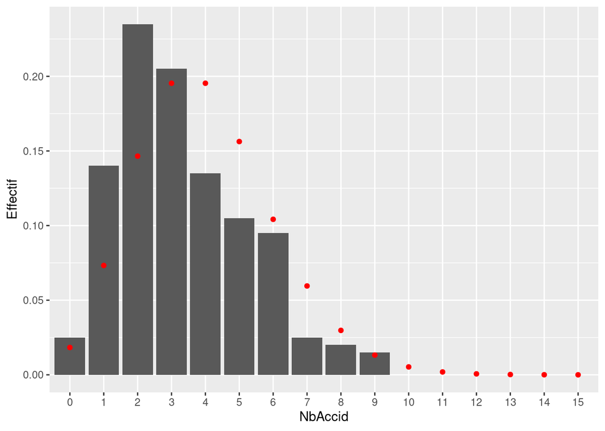

```r
df=data.frame(Accid,Poisson=dpois(Accid[,1],lambda=4))
df$NbAccid = as.factor(df$NbAccid)
df$Effectif = df$Effectif/sum(df$Effectif)
ggplot(data=df)+
  geom_bar(aes(x=NbAccid, y=Effectif),stat= "identity")+
  geom_point(aes(x=NbAccid,y=Poisson),col="red")
```

- On souhaite ici faire un test du khi-deux mais le support de la loi est infini. On va donc se ramener à un support fini en créant des classes de “modalités” $\mathcal C_k$ d’effectifs théoriques $n p_k^0 \geq 5$.

```r
n=sum(Accid[,2])
np0 = n*dpois(0:15,4)
print(cbind(0:15,np0))
```

```
                  np0
 [1,]  0  3.663127778
 [2,]  1 14.652511111
 [3,]  2 29.305022222
 [4,]  3 39.073362963
 [5,]  4 39.073362963
 [6,]  5 31.258690370
 [7,]  6 20.839126913
 [8,]  7 11.908072522
 [9,]  8  5.954036261
[10,]  9  2.646238338
[11,] 10  1.058495335
[12,] 11  0.384907395
[13,] 12  0.128302465
[14,] 13  0.039477682
[15,] 14  0.011279338
[16,] 15  0.003007823
```

```r
np0g = c(sum(np0[1:2]),np0[3:8],sum(np0[9:16]))
np0g[8] = n - sum(np0g[1:7])
rbind(c("<=1","2","3","4","5","6","7",">=8"),np0g)
```

```
     [,1]               [,2]               [,3]
     "<=1"              "2"                "3"
np0g "18.3156388887342" "29.3050222219747" "39.0733629626329"
     [,4]               [,5]               [,6]
     "4"                "5"                "6"
np0g "39.0733629626329" "31.2586903701063" "20.8391269134042"
     [,7]               [,8]
     "7"                ">=8"
np0g "11.9080725219453" "10.2267231585695"
```

- Faites un test du khi-deux pour savoir s’il est pertinent au vu des données de modéliser le nombre d’accidents du travail par semaine par une loi de Poisson $\mathcal P(4)$.

```r
# A COMPLETER
```

Commentaire : …

- Reprenez le raisonnement pour tester si on peut modéliser le nombre d’accidents du travail par semaine par une loi de Poisson (sans fixer le paramètre).

```r
# A COMPLETER
```

Commentaire : …

# 4 Comparaison de 2 échantillons appariés

Dans une usine, on a du mal à fixer le taux d’acidité des yaourts. Sur les mêmes 10 pots, on mesure leur taux d’acidité à la fabrication (0h) et après 5 heures de fabrication. On obtient les valeurs suivantes :

```r
acidite0 = c(12.51,12.48,12.91,12.56,12.58,
                    12.82,12.53,12.50,12.51,12.42)
acidite5 = c(12.82,12.79,12.74,12.88,12.82,
                    12.4,12.84,12.81,12.91,12.39)
```

On veut tester s’il existe une différence significative d’acidité entre les deux instants.

On note $X_i$ (resp. $Y_i$) le taux d’acidité du $i$ème pot à $Oh$ (resp. $5h$).

## 4.1 Test de Student de la différence

Les $X_i$ et $Y_i$ ne sont pas indépendants d’où le terme d’appariés. On considère donc l’échantillon des différences $Z=(Z_i = Y_i - X_i)_{1\leq i \leq n}$.

- Faites quelques statistiques descriptives du vecteur $Z$

```r
Z = acidite5 - acidite0
# A COMPLETER
```

- A l’aide des commandes suivantes, testez s’il existe une différence significative d’acidité entre 0h et 5h :

```r
t.test(Z)
```

```
    One Sample t-test

data:  Z
t = 1.8437, df = 9, p-value = 0.09833
alternative hypothesis: true mean is not equal to 0
95 percent confidence interval:
 -0.0358604  0.3518604
sample estimates:
mean of x
    0.158
```

```r
t.test(acidite5,acidite0,paired=T)
```

```
    Paired t-test

data:  acidite5 and acidite0
t = 1.8437, df = 9, p-value = 0.09833
alternative hypothesis: true mean difference is not equal to 0
95 percent confidence interval:
 -0.0358604  0.3518604
sample estimates:
mean difference
          0.158
```

Commentaire : …

- Quelle critique pouvez-vous faire de ce test ? Vous argumenterez votre réponse par un test.

Commentaire : …

```r
# A completer
```

Commentaire : …

## 4.2 Tests non-paramétriques

L’hypothèse de normalité de $Z$ étant rejetée, on s’oriente vers des tests non-paramétriques.

### 4.2.1 Test du signe des $Z_i$

Soit $N=\sum_{i=1}^n \mathbb{1}_{Z_i\geq 0}$.

- Quelle est la loi de $N$ quand la médiane des $Z_i$ est nulle ?
- Testez s’il existe une différence significative d’acidité entre les deux instants à partir de $N$. Vous pouvez utiliser la fonction `binom.test()`.

```r
# A COMPLETER
```

Commentaire : …